# eiCompare: Ecological Inference

This vignette illustrates how we can use the Ecological Inference (EI) tools within `eiCompare` to learn about the voting behavior of different groups of voters.

Note: Some lines of code below are commented out to limit testing time. To run this demo, uncomment them.

## The ecological inference problem

Ecological Inference involves estimating the voting behaviors of different groups of voters using only data about election results and the number of people from each group that turned out to vote. Elections in the United States, and much of the rest of the world, use secret ballots that ensure confidentiality for every voter. Voter confidentiality is important for a functioning democracy, but it presents a problem for those who want to learn about voter behavior. We cannot directly measure how people vote in an election. Intead, we have to make inferences about how they might have voted using election results and information about voter turnout. We often end up with datasets like the following, which contains aggregate election results and turnout information for each election precinct in Gwinnett County, Georgia:

```r
suppressPackageStartupMessages({
  library(eiCompare)
  library(dplyr)
})

data("gwinnett")
head(gwinnett)
```

```
#>   precinct turnout kemp abrams metz white black hispanic other
#> 1      001    3718 1835   1842   41  1862  1247      211   522
#> 2      002    2251  434   1805   12   455  1447       68   268
#> 3      003    2721 1156   1532   33  1147   850      220   399
#> 4      004     875  402    456   17   522   188       36   134
#> 5      005    1765  963    783   19  1004   477       36   222
#> 6      006    2116  841   1248   27   915   520      255   394
```

This dataset contains the following columns:

- `precinct` - This uniquely identifies each precinct in the county.
- `turnout` - The total number of voters who cast ballots on election day
- `kemp`, `abrams`, `metz` - These count the number of votes cast for each candidate.
- `white`, `black`, `hispanic`, `other` - These count the number of voters who self-reported as each race group.

Election results by precinct are generally accessible online from election administrators. Measuring the turnout of different racial/ethnic groups, however, can present more of a challenge. Luckily, the state of Georgia requires voters to self-report their race when they register. This means anyone can tabulate the number of voters self-reporting with each group in each precinct, provided they gain access to a voter file. That’s exactly what we’ve done here. To learn more about how to estimate voters’ race based only on their name and address, see the tutorial on Bayesian Improved Surname Geocoding

We know the number of votes cast for each candidate and by each racial/ethnic group. From this data, we want to learn whether voters from different ethnic groups prefer different candidates.

## Preparing the data

First, we need to clean and prepare the data. `eiCompare` contains functions to streamline data preparation and prevent common errors that emerge during this process.

First, let’s set up our column vectors. Most `eiCompare` functions for ecological inference require these as parameters.

```r
cands <- c("kemp", "abrams", "metz")
races <- c("white", "black", "hispanic", "other")
total <- "turnout"
id <- "precinct"
```

We start by dealing with all the missing values in the our dataset. For this, we can use the function `resolve_missing_vals()` from the `eiCompare` package. This function checks looks for missing values in they important columns of the dataframe. It currently has two options for handling missing values.

1. `na_action = "DROP"`: The function will drop any row with a missing value.
2. `na_action = "MEAN"`: The function will replace missing values in these columns with their respective column’s mean value.

```r
gwinnett <- resolve_missing_vals(
  data = gwinnett,
  cand_cols = cands,
  race_cols = races,
  totals_col = total,
  na_action = "DROP"
)
```

```
#> No missing values in key columns. Returning original dataframe...
```

Looks like this dataset doesn’t contain any missing values. We can proceed to the next step. Next, we use `dedupe_precincts()` to check that the data does not contain anyduplicate precincts.

```r
gwinnett <- dedupe_precincts(
  data = gwinnett,
  id_cols = id
)
```

```
#> Warning in dedupe_precincts(data = gwinnett, id_cols = id): Precincts appear duplicated. Returning boolean column identifying
#> duplicates...
```

We got a warning indicating that some rows of the data do appear to belong to the same precinct. When `dedupe_precincts()` identifies duplicates that it does not know how to resolve, the function returns a column called `duplicate` that highlights the duplicated rows. This helps us investigate the duplicates and try to figure out where they came from. Let’s take a look at these now.

```r
gwinnett %>%
  filter(duplicate)
```

```
#>   precinct turnout kemp abrams metz white black hispanic other duplicate
#> 1      035    1658  803    835   20  1100   525       81   362      TRUE
#> 2      035     368  159    207    2  1100   525       81   362      TRUE
```

Here we see that precinct `035` appears to have entered the data twice. This anomaly has at least two possible explanations:

1. For most elections, precincts report their own results and data entry is often done by hand. This can lead to small mistakes like a precincts’ vote tallies being split over two rows.
2. Election results databases typically contain the resutls of many elections that took place in different jurisdictions and at different times. When extracting the results of a particular election, an easy mistake is to accidentally extract some results from other elections, leading to repeated precinct IDs.

In this case, we have confidence that this duplicate has emerged through an error in precinct reporting. We can combine the two columns using this code:

```r
missing_inds <- which(gwinnett$duplicate)
columns_to_add <- c(total, cands)
gwinnett[missing_inds[1], columns_to_add] <-
  gwinnett[missing_inds[1], columns_to_add] +
  gwinnett[missing_inds[2], columns_to_add]
gwinnett <- gwinnett[-missing_inds[2], ]
gwinnett[missing_inds[1], ]
```

```
#>    precinct turnout kemp abrams metz white black hispanic other duplicate
#> 35      035    2026  962   1042   22  1100   525       81   362      TRUE
```

Now we see the vote totals from the previous two columns have been summed together in this new row. We can double check that this eliminated all duplicates be running `dedupe_precincts()` again.

```r
gwinnett <- dedupe_precincts(
  data = gwinnett,
  id_cols = id
)
```

```
#> Data does not contain duplicates. Proceed...
```

Now we’re sure that our dataset does not contain any missing values or duplicated precincts. We can proceed with standardizing the data. To execute ecological inference cleanly, we need to make sure to represent our data in proportions that sum to one. Not doing this can cause the EI functions to break or behave unexpectedly. For this, we can use `stdize_votes_all()`.

```r
gwinnett_ei <- stdize_votes_all(
  data = gwinnett,
  cand_cols = cands,
  race_cols = races,
  totals_col = total
)
```

```
#> Using provided totals...
#> Standardizing candidate columns...
#> All columns sum correctly. Computing proportions...
#> Standardizing race columns...
#> Vote sums deviate from totals.
#> Deviations are minor. Restandardizing vote columns...
```

```r
head(gwinnett_ei)
```

```
#>     kemp abrams     metz  white  black hispanic  other turnout
#> 1 0.4935 0.4954 0.011027 0.4846 0.3246  0.05492 0.1359    3718
#> 2 0.1928 0.8019 0.005331 0.2033 0.6466  0.03038 0.1197    2251
#> 3 0.4248 0.5630 0.012128 0.4385 0.3249  0.08410 0.1525    2721
#> 4 0.4594 0.5211 0.019429 0.5932 0.2136  0.04091 0.1523     875
#> 5 0.5456 0.4436 0.010765 0.5773 0.2743  0.02070 0.1277    1765
#> 6 0.3974 0.5898 0.012760 0.4391 0.2495  0.12236 0.1891    2116
```

This function has produced a new dataframe where each column is a proportion. We can check that for each row, the candidate columns sum to one and the race columns sum to one using the following code.

```r
cand_sums <- sum_over_cols(data = gwinnett_ei, cols = cands)
race_sums <- sum_over_cols(data = gwinnett_ei, cols = races)
table(cand_sums, race_sums)
```

```
#>          race_sums
#> cand_sums   1
#>         1 156
```

Here we see that, for each row in the dataset, the sum of the race columns equals one, and the sum of the candidate columns also equals one. We *always* need to satisfy this condition before running the EI functions.

We now have a new dataframe without missing values, with no duplicated precincts, and with standardized candidate and racial vote proportion colums. We can begin conducting ecological inference.

## Descriptive Analysis

Now that we’ve cleaned and prepared the data, we’re ready to begin analyzing it. Before running ecological inference, it’s useful to conduct some simple descriptive analyses. First, let’s plot the precinct-level bivariate relationships between all the different combinations of racial and candidate turnout proportions.

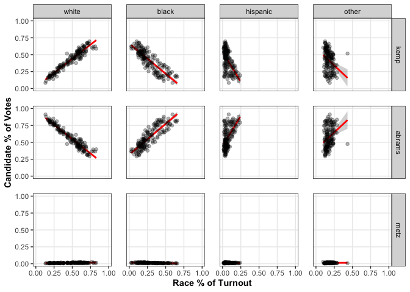

```r
plot_bivariate(
  data = gwinnett_ei,
  cand_cols = cands,
  race_cols = races
)
```

The `plot_bivariate()` function returns a `ggplot2` object plotting the relationships between each candidate’s precinct-level vote share and the precinct-level turnout share of each race group. These plots can tell us a lot about what to expect from the EI analysese to come. In particular, we can observe the following two trends.

1. We observe what looks like racially polarized voting in the top left corner of this figure. The panel in the upper left corner shows that as the proportion of white voters in a precinct rises, so does the proportion of votes for Brian Kemp. The plot just below shows that the opposite is true for Stacey Abrams. Meanwhile, the second column reveals the opposite pattern for black voters. This is a sign that racially polarized voting might be going on in this election. We can use EI to back this up statistically.
2. The bottom row shows that Jim Metz received very few votes across precincts. Because there is so little variation in levels of vote share for this candidate, our EI estimates probably will not detect racially polarized voting for this candidate. We can expect similarly from the ‘hispanic’ and ‘other’ race categories, since few districts have very high proportions of these groups.

We can also get the simple correlation coefficients for each bivariate relationship using the `race_cand_cors()` function.

```r
race_cand_cors(
  data = gwinnett_ei,
  cand_cols = cands,
  race_cols = races
)
```

```
#>          white   black hispanic   other
#> kemp    0.9593 -0.8538  -0.5793 -0.3089
#> abrams -0.9618  0.8602   0.5751  0.3028
#> metz    0.5622 -0.6538  -0.1286  0.0726
```

For black, white and hispanic voters we observe strong correlations between racial composition and the share of votes going to each candidate. This provides further a indication that ecological inference may reveal racially polarized voting.

These basic descriptive checks help us understand our data and give us a sense of what to expect in our final results. Next, we turn to executing and comparing the different EI techniques.

## Ecological Inference

`eiCompare` enables users to analyze and compare the two dominant EI methods, Iterative EI and RxC EI. For more information about these techniques, see the [technical details](https://rpvote.github.io/voting-rights/methods/) page of our website.

We can run both methods with their respective functions. They take some time to run because they both compute point estimates by sampling from a distribution.

First, we conduct iterative EI using `ei_iter()`.

```r
# ei_results_iter <- ei_iter(
#  data = gwinnett_ei,
#  cand_cols = cands,
#  race_cols = races,
#  totals_col = total,
#  name = "Iter",
#)
#summary(ei_results_iter)
```

Notice that the `name` field is used to give a name to the results object. The name entered here is what differentiates results objects from each other when they are summarized or plotted together. Next, we conduct RxC EI using `ei_rxc()`. This function uses a Markov Chain Monte Carlo (MCMC) algorithm to compute estimates. Here, the MCMC parameters are set to prioritize speed over accuracy. In practice, to ensure robust results, users should use at least the default number of samples (probably more), and check the diagnostics of the MCMC chain to ensure that everything worked correctly.

```r
#ei_results_rxc <- ei_rxc(
#  data = gwinnett_ei,
#  cand_cols = cands,
#  race_cols = races,
#  totals_col = total,
#  ntunes = 1,
#  samples = 5000,
#  thin = 1,
#  name = "RxC"
#)
#summary(ei_results_iter, ei_results_rxc)
```

Here we use the `eiCompare` `summary()` method to compare multiple ecological inference estimates. This is where the name `eiCompare` comes from!

Finally, we can plot the results of the two methods using the eiCompare `plot()` method. This method accepts a list of `eiCompare` objects outputted by `ei_iter()` and `ei_rxc()`. It plots the point estimates and 95% credible intervals for each candidate-race pair, for however many objects are passed in.

```r
#plot(ei_results_iter, ei_results_rxc)
```

The plotting and summary methods can be used to compare across different methods of ecological inference, or different specifications of the same method.

## Summary

This vignette has provided a brief overview of the workflow for using `eiCompare` to conduct ecological inference. It introduced the following functions:

- `resolve_missing_vals()`
- `dedupe_precincts()`
- `stdize_votes_all()`
- `plot_bivariate()`
- `race_cand_cors()`
- `ei_iter()`
- `ei_rxc()`
- `summary()`
- `plot()`